# titanic_data_science_project

## **Titanic Data Science Project**

### **Objectives**

- **Load and explore** the Titanic dataset using Python and pandas.
- **Identify patterns and trends** in survival rates based on different passenger attributes.
- **Handle missing data** appropriately and justify your approach.
- Apply **feature engineering** and make informed decisions about which variables to include or exclude.
- **Communicate insights** effectively by explaining your methodology and findings using markdown explanations and well-commented code.

skills: **data cleaning, transformation, and exploratory analysis**

### **Main Task**

**Which groups of passengers were more likely to survive the Titanic disaster?**

#### ✅ **Survival Patterns**

- Identify and describe patterns in survival based on passenger characteristics
- Support your conclusions using relevant visuals and/or grouped statistics
- Explain your methodology: how did you arrive at these conclusions?

#### ✅ **Attribute Selection**

- List the features you chose to include in your analysis
- Briefly explain why each was relevant to your investigation
- Demonstrate how you used these features in your code

#### ✅ **Feature Engineering & Variable Exclusion**

- If you created any new features (e.g., title from name, family size), describe the logic behind them and how they helped
- If you excluded any variables, justify your decision (e.g., due to redundancy or irrelevance)

#### ✅ **Missing Data Handling**

- Identify where missing data appears in the dataset
- Explain the method(s) you used to address it (e.g., dropping, imputing)
- Reflect on how your handling of missing data might affect the analysis

### **1. Load and Explore Titanic Data Set (train.csv)**

##### **1.1 Load Data Set**

```python
import pandas as pd
```

```python
df = pd.read_csv("train.csv")
```

##### **1.2 Expore Data Set**

```python
#Number of rows and columns (a tuple representing dimensions of the DataFrame)
print(df.shape)
```

```
(891, 12)
```

```python
#Overview of the data
df.info()
```

```
<class 'pandas.core.frame.DataFrame'>
RangeIndex: 891 entries, 0 to 890
Data columns (total 12 columns):
 #   Column       Non-Null Count  Dtype
---  ------       --------------  -----
 0   PassengerId  891 non-null    int64
 1   Survived     891 non-null    int64
 2   Pclass       891 non-null    int64
 3   Name         891 non-null    object
 4   Sex          891 non-null    object
 5   Age          714 non-null    float64
 6   SibSp        891 non-null    int64
 7   Parch        891 non-null    int64
 8   Ticket       891 non-null    object
 9   Fare         891 non-null    float64
 10  Cabin        204 non-null    object
 11  Embarked     889 non-null    object
dtypes: float64(2), int64(5), object(5)
memory usage: 83.7+ KB
```

```python
#First 5 rows of the DataFrame
df.head(5)
```

|  | PassengerId | Survived | Pclass | Name | Sex | Age | SibSp | Parch | Ticket | Fare | Cabin | Embarked |
| --- | --- | --- | --- | --- | --- | --- | --- | --- | --- | --- | --- | --- |
| 0 | 1 | 0 | 3 | Braund, Mr. Owen Harris | male | 22.0 | 1 | 0 | A/5 21171 | 7.2500 | NaN | S |
| 1 | 2 | 1 | 1 | Cumings, Mrs. John Bradley (Florence Briggs Th... | female | 38.0 | 1 | 0 | PC 17599 | 71.2833 | C85 | C |
| 2 | 3 | 1 | 3 | Heikkinen, Miss. Laina | female | 26.0 | 0 | 0 | STON/O2. 3101282 | 7.9250 | NaN | S |
| 3 | 4 | 1 | 1 | Futrelle, Mrs. Jacques Heath (Lily May Peel) | female | 35.0 | 1 | 0 | 113803 | 53.1000 | C123 | S |
| 4 | 5 | 0 | 3 | Allen, Mr. William Henry | male | 35.0 | 0 | 0 | 373450 | 8.0500 | NaN | S |

```python
#Last 5 rows of the DataFrame
df.tail(5)
```

|  | PassengerId | Survived | Pclass | Name | Sex | Age | SibSp | Parch | Ticket | Fare | Cabin | Embarked |
| --- | --- | --- | --- | --- | --- | --- | --- | --- | --- | --- | --- | --- |
| 886 | 887 | 0 | 2 | Montvila, Rev. Juozas | male | 27.0 | 0 | 0 | 211536 | 13.00 | NaN | S |
| 887 | 888 | 1 | 1 | Graham, Miss. Margaret Edith | female | 19.0 | 0 | 0 | 112053 | 30.00 | B42 | S |
| 888 | 889 | 0 | 3 | Johnston, Miss. Catherine Helen "Carrie" | female | NaN | 1 | 2 | W./C. 6607 | 23.45 | NaN | S |
| 889 | 890 | 1 | 1 | Behr, Mr. Karl Howell | male | 26.0 | 0 | 0 | 111369 | 30.00 | C148 | C |
| 890 | 891 | 0 | 3 | Dooley, Mr. Patrick | male | 32.0 | 0 | 0 | 370376 | 7.75 | NaN | Q |

##### **1.3 Sorting and Filtering Data**

```python
#Sorting the DataFrame by the "Age" column in ascending order (From youngest to oldest)
df.sort_values(by="Age", ascending=True)

#Youngest passenger was 0.42 years old
```

|  | PassengerId | Survived | Pclass | Name | Sex | Age | SibSp | Parch | Ticket | Fare | Cabin | Embarked |
| --- | --- | --- | --- | --- | --- | --- | --- | --- | --- | --- | --- | --- |
| 803 | 804 | 1 | 3 | Thomas, Master. Assad Alexander | male | 0.42 | 0 | 1 | 2625 | 8.5167 | NaN | C |
| 755 | 756 | 1 | 2 | Hamalainen, Master. Viljo | male | 0.67 | 1 | 1 | 250649 | 14.5000 | NaN | S |
| 644 | 645 | 1 | 3 | Baclini, Miss. Eugenie | female | 0.75 | 2 | 1 | 2666 | 19.2583 | NaN | C |
| 469 | 470 | 1 | 3 | Baclini, Miss. Helene Barbara | female | 0.75 | 2 | 1 | 2666 | 19.2583 | NaN | C |
| 78 | 79 | 1 | 2 | Caldwell, Master. Alden Gates | male | 0.83 | 0 | 2 | 248738 | 29.0000 | NaN | S |
| ... | ... | ... | ... | ... | ... | ... | ... | ... | ... | ... | ... | ... |
| 859 | 860 | 0 | 3 | Razi, Mr. Raihed | male | NaN | 0 | 0 | 2629 | 7.2292 | NaN | C |
| 863 | 864 | 0 | 3 | Sage, Miss. Dorothy Edith "Dolly" | female | NaN | 8 | 2 | CA. 2343 | 69.5500 | NaN | S |
| 868 | 869 | 0 | 3 | van Melkebeke, Mr. Philemon | male | NaN | 0 | 0 | 345777 | 9.5000 | NaN | S |
| 878 | 879 | 0 | 3 | Laleff, Mr. Kristo | male | NaN | 0 | 0 | 349217 | 7.8958 | NaN | S |
| 888 | 889 | 0 | 3 | Johnston, Miss. Catherine Helen "Carrie" | female | NaN | 1 | 2 | W./C. 6607 | 23.4500 | NaN | S |

891 rows × 12 columns

```python
#Sorting the DataFrame by the "Age" column in descending order (From oldest to youngest)
df.sort_values(by="Age", ascending=False)

#Oldest passenger was 80 years old
```

|  | PassengerId | Survived | Pclass | Name | Sex | Age | SibSp | Parch | Ticket | Fare | Cabin | Embarked |
| --- | --- | --- | --- | --- | --- | --- | --- | --- | --- | --- | --- | --- |
| 630 | 631 | 1 | 1 | Barkworth, Mr. Algernon Henry Wilson | male | 80.0 | 0 | 0 | 27042 | 30.0000 | A23 | S |
| 851 | 852 | 0 | 3 | Svensson, Mr. Johan | male | 74.0 | 0 | 0 | 347060 | 7.7750 | NaN | S |
| 493 | 494 | 0 | 1 | Artagaveytia, Mr. Ramon | male | 71.0 | 0 | 0 | PC 17609 | 49.5042 | NaN | C |
| 96 | 97 | 0 | 1 | Goldschmidt, Mr. George B | male | 71.0 | 0 | 0 | PC 17754 | 34.6542 | A5 | C |
| 116 | 117 | 0 | 3 | Connors, Mr. Patrick | male | 70.5 | 0 | 0 | 370369 | 7.7500 | NaN | Q |
| ... | ... | ... | ... | ... | ... | ... | ... | ... | ... | ... | ... | ... |
| 859 | 860 | 0 | 3 | Razi, Mr. Raihed | male | NaN | 0 | 0 | 2629 | 7.2292 | NaN | C |
| 863 | 864 | 0 | 3 | Sage, Miss. Dorothy Edith "Dolly" | female | NaN | 8 | 2 | CA. 2343 | 69.5500 | NaN | S |
| 868 | 869 | 0 | 3 | van Melkebeke, Mr. Philemon | male | NaN | 0 | 0 | 345777 | 9.5000 | NaN | S |
| 878 | 879 | 0 | 3 | Laleff, Mr. Kristo | male | NaN | 0 | 0 | 349217 | 7.8958 | NaN | S |
| 888 | 889 | 0 | 3 | Johnston, Miss. Catherine Helen "Carrie" | female | NaN | 1 | 2 | W./C. 6607 | 23.4500 | NaN | S |

891 rows × 12 columns

```python
#Sorting the "Age" column with passengers younger than 10 years old

train = df[df["Age"] < 10]
train
train.info
```

```
<bound method DataFrame.info of      PassengerId  Survived  Pclass                                      Name  \
7              8         0       3            Palsson, Master. Gosta Leonard
10            11         1       3           Sandstrom, Miss. Marguerite Rut
16            17         0       3                      Rice, Master. Eugene
24            25         0       3             Palsson, Miss. Torborg Danira
43            44         1       2  Laroche, Miss. Simonne Marie Anne Andree
..           ...       ...     ...                                       ...
827          828         1       2                     Mallet, Master. Andre
831          832         1       2           Richards, Master. George Sibley
850          851         0       3   Andersson, Master. Sigvard Harald Elias
852          853         0       3                   Boulos, Miss. Nourelain
869          870         1       3           Johnson, Master. Harold Theodor

        Sex   Age  SibSp  Parch           Ticket     Fare Cabin Embarked
7      male  2.00      3      1           349909  21.0750   NaN        S
10   female  4.00      1      1          PP 9549  16.7000    G6        S
16     male  2.00      4      1           382652  29.1250   NaN        Q
24   female  8.00      3      1           349909  21.0750   NaN        S
43   female  3.00      1      2    SC/Paris 2123  41.5792   NaN        C
..      ...   ...    ...    ...              ...      ...   ...      ...
827    male  1.00      0      2  S.C./PARIS 2079  37.0042   NaN        C
831    male  0.83      1      1            29106  18.7500   NaN        S
850    male  4.00      4      2           347082  31.2750   NaN        S
852  female  9.00      1      1             2678  15.2458   NaN        C
869    male  4.00      1      1           347742  11.1333   NaN        S

[62 rows x 12 columns]>
```

### **2. Data Cleaning - Handling Missing Data**

##### **2.1 Identify where missing data appears in the dataset**

```python
#Check for missing values
df.info()
```

```
<class 'pandas.core.frame.DataFrame'>
RangeIndex: 891 entries, 0 to 890
Data columns (total 12 columns):
 #   Column       Non-Null Count  Dtype
---  ------       --------------  -----
 0   PassengerId  891 non-null    int64
 1   Survived     891 non-null    int64
 2   Pclass       891 non-null    int64
 3   Name         891 non-null    object
 4   Sex          891 non-null    object
 5   Age          714 non-null    float64
 6   SibSp        891 non-null    int64
 7   Parch        891 non-null    int64
 8   Ticket       891 non-null    object
 9   Fare         891 non-null    float64
 10  Cabin        204 non-null    object
 11  Embarked     889 non-null    object
dtypes: float64(2), int64(5), object(5)
memory usage: 83.7+ KB
```

Out of total of 891 entries we can see some values are missing for these columns

- Column 5: Age
- Column 10: Cabin
- Column 11: Embarked

```python
#Check for missing values in the entire DataFrame
missing_data = df.isnull().sum()
print(missing_data)
```

```
PassengerId      0
Survived         0
Pclass           0
Name             0
Sex              0
Age            177
SibSp            0
Parch            0
Ticket           0
Fare             0
Cabin          687
Embarked         2
dtype: int64
```

Numbers of missing values per column are

- 177 values from Age column is missing
- 687 values from Cabin column is missing
- 2 values from Embarked Column is missing

Strategy:

- Cabin: It is reasonable to not use Cabin data for analysis as too many values are missing
- Age: Need to find a way to replace missing values (imputation). Possibly through using median age grouped by Pclass and sex (or Title)
- Embarked: Impute with most common value as only 2 values are missing

```python
#Detect missing values in the Age column of df
bool_series = df['Age'].isnull()
missing_age_data = df[bool_series]
print(missing_age_data)
```

```
     PassengerId  Survived  Pclass                                      Name  \
5              6         0       3                          Moran, Mr. James
17            18         1       2              Williams, Mr. Charles Eugene
19            20         1       3                   Masselmani, Mrs. Fatima
26            27         0       3                   Emir, Mr. Farred Chehab
28            29         1       3             O'Dwyer, Miss. Ellen "Nellie"
..           ...       ...     ...                                       ...
859          860         0       3                          Razi, Mr. Raihed
863          864         0       3         Sage, Miss. Dorothy Edith "Dolly"
868          869         0       3               van Melkebeke, Mr. Philemon
878          879         0       3                        Laleff, Mr. Kristo
888          889         0       3  Johnston, Miss. Catherine Helen "Carrie"

        Sex  Age  SibSp  Parch      Ticket     Fare Cabin Embarked
5      male  NaN      0      0      330877   8.4583   NaN        Q
17     male  NaN      0      0      244373  13.0000   NaN        S
19   female  NaN      0      0        2649   7.2250   NaN        C
26     male  NaN      0      0        2631   7.2250   NaN        C
28   female  NaN      0      0      330959   7.8792   NaN        Q
..      ...  ...    ...    ...         ...      ...   ...      ...
859    male  NaN      0      0        2629   7.2292   NaN        C
863  female  NaN      8      2    CA. 2343  69.5500   NaN        S
868    male  NaN      0      0      345777   9.5000   NaN        S
878    male  NaN      0      0      349217   7.8958   NaN        S
888  female  NaN      1      2  W./C. 6607  23.4500   NaN        S

[177 rows x 12 columns]
```

##### **2.2 Explain the method(s) you used to address it (e.g., dropping, imputing)**

**1. Age (177 missing values)**

- Method: Imputing using the median age grouped by Title, Sex, and Pclass
- Reasoning: Age varies significantly by title (ex. Miss, Ms, Mrs, Master, Mr) and Pclass

```python
#Extract the titles from the "Name" column
df['Title'] = df['Name'].str.extract(r' ([A-Za-z]+)\.', expand=False)

df['Age'] = df.groupby(['Title', 'Pclass', 'Sex'])['Age'].transform(lambda x: x.fillna(x.median()))

print(df['Age'].isnull().sum())
```

```
0
```

**2. Embarked (2 missing values)**

```python
df['Embarked'].fillna(df['Embarked'].mode()[0])
```

```
0      S
1      C
2      S
3      S
4      S
      ..
886    S
887    S
888    S
889    C
890    Q
Name: Embarked, Length: 891, dtype: object
```

**3. Cabin (687 missing values)**

- Method: Dropping; exclude the column from analysis.
- Reasoning: Too much missing values result in unreliable analysis or not significant results

```python
#df.drop(columns=['Cabin'], inplace=True)
#Will be actually dropping the Cabin column later in excluded features
```

```python
#Check for missing values in the entire DataFrame
missing_data = df.isnull().sum()
print(missing_data)
```

```
PassengerId      0
Survived         0
Pclass           0
Name             0
Sex              0
Age              0
SibSp            0
Parch            0
Ticket           0
Fare             0
Cabin          687
Embarked         2
Title            0
dtype: int64
```

##### **2.3 Reflect on how your handling of missing data might affect the analysis**

While it still depends on how much missing data exists in the data frame, I learned how handling missing data could significantly affect the analysis later on. As a data analyst, I decide how the missing data is replaced and interpreted, which can change the patterns and trends in the data.

I tried to recover the values of missing data without greatly harming or altering the existing data. By using Pclass, Title, and Sex for missing age data, I believe it is possible to achieve reasonable age imputation. I think it is important to consider the historical background and sociological information at the time (1900s).

### **3. Transformation - Feature Engineering & Variable Exclusion**

##### **3.1 Describe the logic behind any new features and how they helped**

```python
# Extract last name from the Name column
df['LastName'] = df['Name'].str.extract(r'([A-Za-z]+),', expand=False)

# Calculate family size based on SibSp and Parch (immediate family on board)
df['FamilySize_SibParch'] = df['SibSp'] + df['Parch'] + 1

# Count how many times each last name appears (extended family/group)
last_name_counts = df['LastName'].value_counts()
df['FamilySize_LastName'] = df['LastName'].map(last_name_counts)

# Choose the maximum of the two as the family size feature
df['FamilySize'] = df[['FamilySize_SibParch', 'FamilySize_LastName']].max(axis=1)

print(df[['FamilySize']].value_counts().sort_index())
```

```
FamilySize
1             454
2             174
3             127
4              61
5              15
6              34
7               4
8               6
9               9
11              7
Name: count, dtype: int64
```

```python
#Make Age column is all float type
df['Age'] = df['Age'].astype(float)

#Define bins and labels for age groups
age_bins = [0.0, 1.0, 15.0, 25.0, 45.0, 65.0, 100.0]
age_labels = ['Infant', 'Children', 'Youth', 'Adult', 'MiddleAge', 'Senior']

#Create a new column 'AgeGroup' based on the defined bins and labels
df['AgeGroup'] = pd.cut(df['Age'], bins=age_bins, labels=age_labels)

#Count the occurrences of each age group
print(df[['AgeGroup']].value_counts().sort_index())

#Count total number of sum of each age group
print(df['AgeGroup'].value_counts().sum())
```

```
AgeGroup
Infant        14
Children      73
Youth        253
Adult        448
MiddleAge     95
Senior         8
Name: count, dtype: int64
891
```

Titanic happenend in 1912 So I used age group standard in 1900s

```python
selected_columns = df[['Survived', 'Age', 'Sex', 'Pclass', 'SibSp', 'Parch', 'FamilySize', 'AgeGroup']]
```

##### **Selected Variables**

Survived (Target Variable)

- Indicates wheter a passenger survived (1) or deceased (0)
- Dependent Variable and the outcome to predict

Age

- Age influences survival due to evacuation priorities (Passengers of titanic let women and children evacuate first)
- Used for direct analysis and binning into AgeGroup

Sex

- Women were prioritized during evacuation; gender played a major role in survival

Pclass

- Ticket class is a proxy for socioeconomic status (1st class passengers had better access to lifeboats and probably priorties while evacuation)

SibSp (Siblings/Spouses)

- Family presents in emergency situation could influence survival behavior
- Family could act as supporter or helper in emergency evacuation

Parch (Parents/Children)

- Family presents in emergency situation could influence survival behavior
- Parents could act as supporter or helper in emergency evacuation (Parents will priortize their children survival first)
- Having children and taking care of them during emergency evacuation might lower survival rate

**New Features**

Family Size

- Able to see how having big or small size of family affect in survival

AgeGroup

- Simplifies age analysis by grouping into age group

##### **3.2 If you excluded any variables, justify your decision (e.g., due to redundancy or irrelevance)**

```python
excluded_columns = df[['Name', 'Fare', 'Embarked', 'Ticket', 'Cabin', 'PassengerId']]
```

Name: Irrelevance; does not help prediction as it is mostly unstructured text, we extract title for missing data

Fare: Redundancy; fare reflects wealth but as it is correlated with Pclass, as Pclass is cleaner and more categorical indicator, I exclueded fare

Embarked: Irrelevance; indicated port of embarkation (S, C, Q) which i consider it has low link to survival rate

Ticket: Irrelevance; random strings/numbers with no standard format, made family size to measure group size instead of shared ticket

Cabin: Unrealiable; almost 80% of data was missing while it could be useful if it has more usable data

PassengerId: Irrelvance; no analytical value, it's purely for administrative numbering

### **4. Explatory Analysis - Survival Patterns**

##### **4.1 Identify and describe patterns in survival based on passenger characteristics**

```python
survived_by_age = df.groupby('Age')["Survived"].mean()

# Show survival rate by each age with percentage in index
trend = survived_by_age.apply(lambda x: f"{x:.2%}")
trend.index = [f"Age {age} ({pct})" for age, pct in zip(trend.index, trend.values)]
print(trend.sort_index())
```

```
Age 0.42 (100.00%)    100.00%
Age 0.67 (100.00%)    100.00%
Age 0.75 (100.00%)    100.00%
Age 0.83 (100.00%)    100.00%
Age 0.92 (100.00%)    100.00%
                       ...
Age 71.0 (0.00%)        0.00%
Age 74.0 (0.00%)        0.00%
Age 8.0 (50.00%)       50.00%
Age 80.0 (100.00%)    100.00%
Age 9.0 (25.00%)       25.00%
Name: Survived, Length: 89, dtype: object
```

**1. Survival by Age**

```python
survived_by_sex = df.groupby('Sex')['Survived'].mean()

# Show survival rate by gender with percentage in index
trend = survived_by_sex.apply(lambda x: f"{x:.2%}")
trend.index = [f"{gender} ({pct})" for gender, pct in zip(trend.index, trend.values)]
print(trend)
```

```
female (74.20%)    74.20%
male (18.89%)      18.89%
Name: Survived, dtype: object
```

**2. Survival by Gender**

The analysis shows a big difference in survival rates between men and women. Women had a much higher chance of survival (74%) compared to men (19%). This matches historical accounts that women were given priority during the evacuation of the Titanic. Gender was the single most important factor in the dataset.

```python
survived_by_Pclass = df.groupby('Pclass')['Survived'].mean()

#Show survival rate by Pclass with percentage in index
trend = survived_by_Pclass.apply(lambda x: f"{x:.2%}")
trend.index = [f"Class {cls}" for cls in trend.index]
print(trend)
```

```
Class 1    62.96%
Class 2    47.28%
Class 3    24.24%
Name: Survived, dtype: object
```

**3. Survival by Passenger Class (Pclass)**

Survival rates varied by passenger class. First class had the highest survival rate, second class was second and third class had the lowest. This matches the social hierarchy on board where first class had better cabin access, more lifeboats nearby and possibly faster access to evacuation information.

```python
survived_by_familysize = df.groupby('FamilySize')['Survived'].mean()

# Show survival rate by FamilySize with size and percentage in index
trend = survived_by_familysize.apply(lambda x: f"{x:.2%}")
trend.index = [f"Family Size {size}" for size in trend.index]
print(trend)
```

```
Family Size 1     31.50%
Family Size 2     48.28%
Family Size 3     50.39%
Family Size 4     54.10%
Family Size 5     20.00%
Family Size 6     29.41%
Family Size 7     75.00%
Family Size 8      0.00%
Family Size 9     22.22%
Family Size 11     0.00%
Name: Survived, dtype: object
```

**4. Survival by Family Size**

```python
survived_by_agegroup = df.groupby('AgeGroup')['Survived'].mean()

# Show survival rate by AgeGroup with group and percentage in index
trend = survived_by_agegroup.apply(lambda x: f"{x:.2%}")
trend.index = [f"{group} ({pct})" for group, pct in zip(trend.index, trend.values)]
print(trend)
```

```
Infant (85.71%)       85.71%
Children (53.42%)     53.42%
Youth (37.94%)        37.94%
Adult (35.04%)        35.04%
MiddleAge (38.95%)    38.95%
Senior (12.50%)       12.50%
Name: Survived, dtype: object
```

**5. Survival by Age Group**

When binned into age groups, infants (under 1 year old) had the highest survival rate, children next and teenagers and adults had much lower survival rates. This supports the narrative that children were also prioritized during the rescue. The elderly had the lowest survival rates possibly due to mobility issues and slower response times.

##### **4.2 Support your conclusions using relevant visuals and/or grouped statistics**

[figure not shown]

```python
import matplotlib.pyplot as plt

survived_by_age.plot(kind='bar', title='Survival Rate by Age')
plt.ylabel('Survival Rate')
plt.show()
```

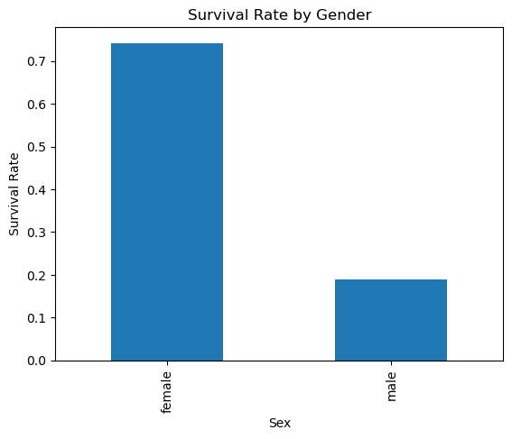

```python
survived_by_sex.plot(kind='bar', title='Survival Rate by Gender')
plt.ylabel('Survival Rate')
plt.show()
```

Female has significantly high survival rate than male

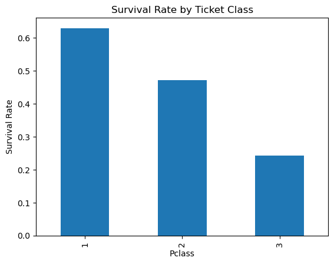

```python
survived_by_Pclass.plot(kind='bar', title='Survival Rate by Ticket Class')
plt.ylabel('Survival Rate')
plt.show()
```

Survival rate is higher for higher class

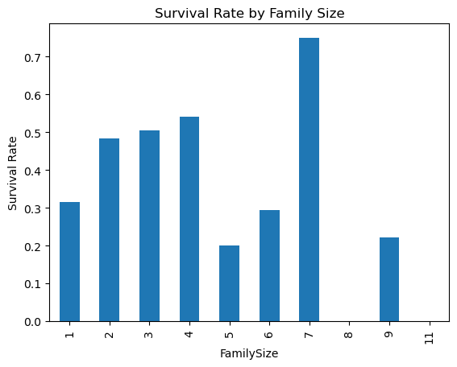

```python
survived_by_familysize.plot(kind='bar', title='Survival Rate by Family Size')
plt.ylabel('Survival Rate')
plt.show()
```

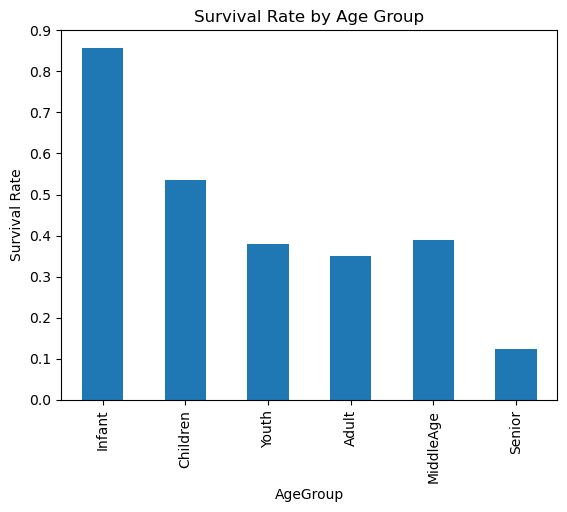

```python
survived_by_agegroup.plot(kind='bar', title='Survival Rate by Age Group')
plt.ylabel('Survival Rate')
plt.show()
```

Infants and children has highest survival rate

Youth, Adult, MiddleAge has similar survival rate 30-40%

Senior has lowest survival rate

### **5. Conclusion and Reflection**

##### **5.2 Reflection**

Feature engineering helped a lot:

- Extracting Title from Name pulled out social roles (e.g., Master, Miss).
- FamilySize got us group-based insights beyond SibSp and Parch.
- Binning Age into AgeGroup made trends more visible.

What to do next:

- I dropped Cabin, but with more data or deck extraction logic, it could have given us spatial survival insights.
- More features (e.g., shared tickets or family IDs) would have helped with group tracking.
- This is mostly descriptive — predictive modeling would take it further.